# Airbnb Price Analysis in R

Yang

# Outline

- Introduction
- Data Collection and Loading
- Data Understanding and Cleaning
- Descriptive Statistics and Geospatial Analysis
- Feature Selection
- Modeling and Predictions

# 1. Introduction

Airbnb, the popular online platform for organizing and providing accommodations, currently boasts a staggering inventory of over 6 million rooms and houses in 81,000 cities. With a vast user base of over 150 million individuals worldwide, Airbnb sees an impressive volume of 2 million guests staying in its rentals on any given night, making it a prominent player in the global lodging industry.

With an extensive number of listings available, determining a fair price for an Airbnb rental poses a significant challenge encountered by all users. This issue holds immense importance for both Airbnb users and property owners, as it directly influences their operations. The fact that 53% of travelers choose Airbnb due to potential cost savings underscores the critical role that pricing plays, as it significantly impacts the demand for rentals [2]. Furthermore, statistics reveal that only 11% of the nearly 500,000 listings in the United States are typically reserved on a given night, indicating ample room for improvement .

To address this issue, our project aims to provide insights into the value of an Airbnb listing. By answering the fundamental question of “How much is an Airbnb listing worth?”, we aim to empower both users and property owners to accurately assess the market value of their offerings. This knowledge will facilitate smoother transactions within the Airbnb market, enhancing the efficiency and profitability of all involved parties.

# 2. Data Collection and Loading

We will be using a training dataset of 74,111 Airbnb listings across 6 major US cities (Boston, Chicago, DC, LA, NYC, SF). The dataset was taken from Kaggle’s “Deloitte Machine Learning Competition”. There are a total of 29 features including: **room_type**, **bathrooms**, **bedrooms**, **beds**, **review_scores_rating**, and **neighbourhood**.

The feature we want to predict is **log_price**.

```r
airbnb_train <- read.csv("Deloitte Airbnb/train.csv")
```

# 3. Data understanding and Cleaning

```r
head(airbnb_train)
```

```
##         id log_price property_type       room_type
## 1  6901257  5.010635     Apartment Entire home/apt
## 2  6304928  5.129899     Apartment Entire home/apt
## 3  7919400  4.976734     Apartment Entire home/apt
## 4 13418779  6.620073         House Entire home/apt
## 5  3808709  4.744932     Apartment Entire home/apt
## 6 12422935  4.442651     Apartment    Private room
##                                                                                                                                                                                                                                                                                                          …
## 1                                                                                                                                                                {"Wireless Internet","Air conditioning",Kitchen,Heating,"Family/kid friendly",Essentials,"Hair dryer",Iron,"translation missing: en.host…
## 2                                                                                              {"Wireless Internet","Air conditioning",Kitchen,Heating,"Family/kid friendly",Washer,Dryer,"Smoke detector","Fire extinguisher",Essentials,Shampoo,Hangers,"Hair dryer",Iron,"translation missing: en.host…
## 3 {TV,"Cable TV","Wireless Internet","Air conditioning",Kitchen,Breakfast,"Buzzer/wireless intercom",Heating,"Family/kid friendly","Smoke detector","Carbon monoxide detector","Fire extinguisher",Essentials,Shampoo,Hangers,"Hair dryer",Iron,"Laptop friendly workspace","translation missing: en.host…
## 4                                                                                                      {TV,"Cable TV",Internet,"Wireless Internet",Kitchen,"Indoor fireplace","Buzzer/wireless intercom",Heating,Washer,Dryer,"Smoke detector","Carbon monoxide detector","First aid kit","Fire extinguis…
## 5                                                                                                                                          {TV,Internet,"Wireless Internet","Air conditioning",Kitchen,"Elevator in building",Heating,"Smoke detector","Carbon monoxide detector","Fire extinguisher",Ess…
## 6                                                                                                                                                         {TV,"Wireless Internet",Heating,"Smoke detector","Carbon monoxide detector","First aid kit","Fire extinguisher",Essentials,Hangers,"Laptop frie…
##   accommodates bathrooms bed_type cancellation_policy cleaning_fee city
```

[output cut: 55 more lines]

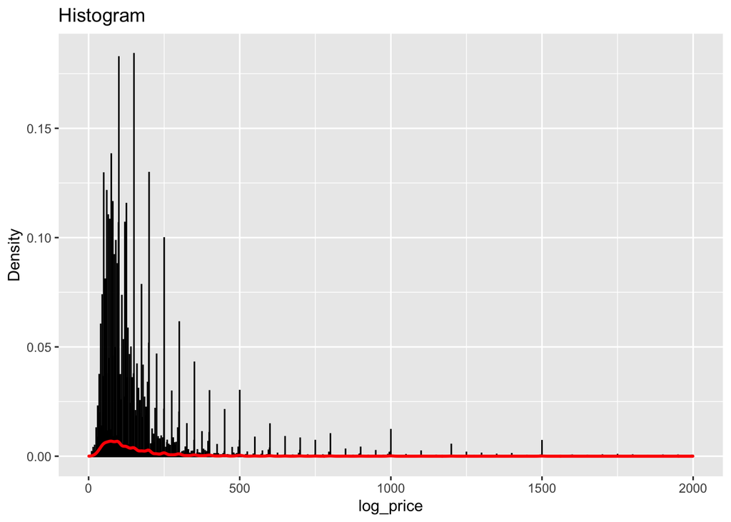

```r
### Take natural logarithm of the price
airbnb_train$price <- exp((airbnb_train$log_price))
ggplot(airbnb_train, aes(x = price)) +
  geom_histogram(aes(y = ..density..), binwidth = 0.2, color = "black", fill = "lightblue") +
  geom_density(color = "red", size = 1) +
  labs(title = "Histogram", x = "log_price", y = "Density")
```

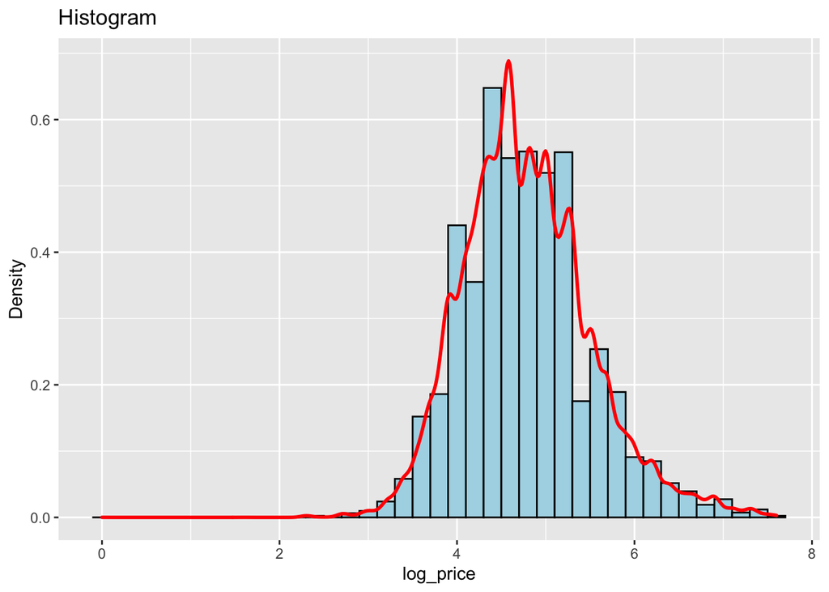

```r
ggplot(airbnb_train, aes(x = log_price)) +
  geom_histogram(aes(y = ..density..), binwidth = 0.2, color = "black", fill = "lightblue") +
  geom_density(color = "red", size = 1) +
  labs(title = "Histogram", x = "log_price", y = "Density")
```

```r
### The distribution of prices will be skewed to the right because most listings cost a modest amount but a few cost a very large amount.Taking the natural logarithm of the price can make the effective relationship non-linear, but still preserving the linear model.
```

```r
### list all variables
num_variables <- ncol(airbnb_train)
variable_names <- colnames(airbnb_train)
cat("Variable names:\n")
```

```
## Variable names:
```

```r
for (variable_name in variable_names) {
  cat(variable_name, "\n")
}
```

```
## id
## log_price
## property_type
## room_type
## amenities
## accommodates
## bathrooms
## bed_type
## cancellation_policy
## cleaning_fee
## city
## description
## first_review
## host_has_profile_pic
## host_identity_verified
## host_response_rate
## host_since
## instant_bookable
## last_review
## latitude
## longitude
## name
## neighbourhood
## number_of_reviews
## review_scores_rating
## thumbnail_url
## zipcode
## bedrooms
## beds
## price
```

```r
### Manually eliminated some features we felt were difficult to use, difficult to enumerate, or unnecessary. The features removed were id, amenities, description, first_review,host_since, host_response_rate, last_review, name, and thumbnail_url. This left us with 19 features to predict log_price with.

airbnb_train1 <- subset(airbnb_train,select = -c(id,amenities,description,first_review,host_since,host_response_rate,last_review,name,thumbnail_url))
```

```r
### Check missing values
### 1. If there is NULL value, input 0
columns_with_null <- colSums(is.na(airbnb_train1)) > 0
cat("Columns with NULL values:", colnames(airbnb_train1)[columns_with_null], "\n")
```

```
## Columns with NULL values: bathrooms review_scores_rating bedrooms beds
```

```r
airbnb_train1[is.na(airbnb_train1)] <- 0

### 2. If there is empty cell, delete those observations
columns_with_empty <- colSums(airbnb_train1 == "") > 0
cat("Columns with empty values:", colnames(airbnb_train1)[columns_with_empty], "\n")
```

```
## Columns with empty values: host_has_profile_pic host_identity_verified neighbourhood zipcode
```

```r
empty_rows_count <- sum(airbnb_train1$host_has_profile_pic == "" | airbnb_train1$host_identity_verified == "" |airbnb_train1$neighbourhood == "" | airbnb_train1$zipcode == "")
cat("Number of rows with empty variables:", empty_rows_count, "\n")
```

```
## Number of rows with empty variables: 7634
```

```r
### there are 7634 rows having empty variables
airbnb_train2 <- airbnb_train1[airbnb_train1$host_has_profile_pic != "" & airbnb_train1$host_identity_verified != "" & airbnb_train1$neighbourhood != "" &airbnb_train1$zipcode != "",,drop=FALSE]
str(airbnb_train2)
```

```
## 'data.frame':    66477 obs. of  21 variables:
##  $ log_price             : num  5.01 5.13 4.98 6.62 4.74 ...
##  $ property_type         : chr  "Apartment" "Apartment" "Apartment" "House" ...
##  $ room_type             : chr  "Entire home/apt" "Entire home/apt" "Entire home/apt" "Entire home/apt" ...
##  $ accommodates          : int  3 7 5 4 2 2 2 2 2 4 ...
##  $ bathrooms             : num  1 1 1 1 1 1 1 1 1 1.5 ...
##  $ bed_type              : chr  "Real Bed" "Real Bed" "Real Bed" "Real Bed" ...
##  $ cancellation_policy   : chr  "strict" "strict" "moderate" "flexible" ...
##  $ cleaning_fee          : chr  "True" "True" "True" "True" ...
##  $ city                  : chr  "NYC" "NYC" "NYC" "SF" ...
##  $ host_has_profile_pic  : chr  "t" "t" "t" "t" ...
##  $ host_identity_verified: chr  "t" "f" "t" "t" ...
##  $ instant_bookable      : chr  "f" "t" "t" "f" ...
##  $ latitude              : num  40.7 40.8 40.8 37.8 38.9 ...
##  $ longitude             : num  -74 -74 -73.9 -122.4 -77 ...
##  $ neighbourhood         : chr  "Brooklyn Heights" "Hell's Kitchen" "Harlem" "Lower Haight" ...
##  $ number_of_reviews     : int  2 6 10 0 4 3 9 159 82 29 ...
##  $ review_scores_rating  : num  100 93 92 0 40 100 93 99 93 97 ...
##  $ zipcode               : chr  "11201" "10019" "10027" "94117.0" ...
##  $ bedrooms              : num  1 3 1 2 0 1 1 1 1 2 ...
##  $ beds                  : num  1 3 3 2 1 1 1 1 1 2 ...
##  $ price                 : num  150 169 145 750 115 85 120 120 100 150 ...
```

```r
### After missing value adjustment, now 66477 observations left in dataset.
```

# 4. Descriptive Statistics and Geospatial Analysis

```r
summary(airbnb_train2$price)
```

```
##    Min. 1st Qu.  Median    Mean 3rd Qu.    Max.
##       1      75     115     162     189    1999
```

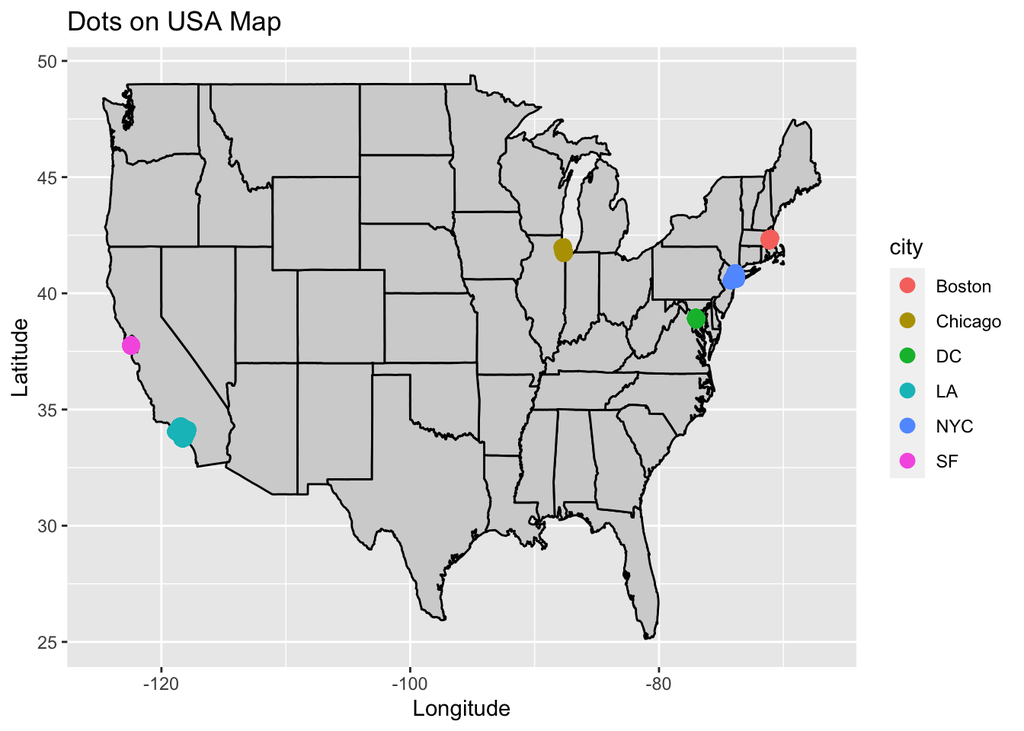

```r
usa_map <- map_data("state")
ggplot() +
  geom_polygon(data = usa_map, aes(x = long, y = lat, group = group), fill = "lightgray", color = "black") +
  geom_point(data = airbnb_train2, aes(x = longitude, y = latitude, color = city), size = 3) +
  labs(title = "Dots on USA Map", x = "Longitude", y = "Latitude")
```

```r
### 2 West Coast: Los Angeles, San Francisco; East Coast: Boston, New York, Washington D.C.;Midwestern: Chicago.

count_by_city <- table(airbnb_train2$city)
print(count_by_city)
```

```
##
##  Boston Chicago      DC      LA     NYC      SF
##    3442    3058    4889   17021   31721    6346
```

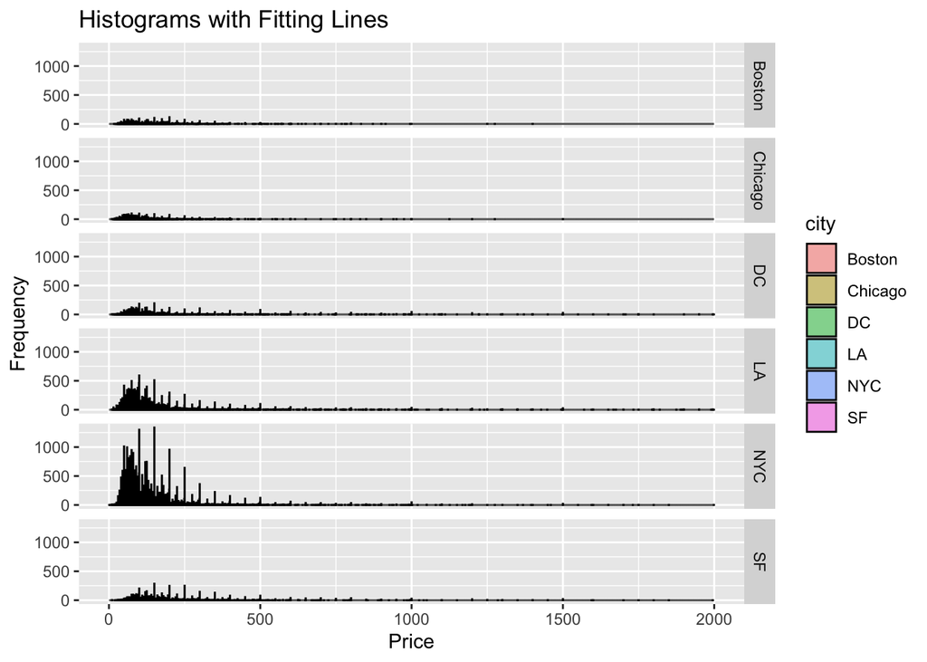

```r
ggplot(airbnb_train2, aes(x = price, fill = city)) +
  geom_histogram(binwidth = 0.5, color = "black", alpha = 0.5) +
  facet_grid(city~.) +
  labs(title = "Histograms with Fitting Lines", x = "Price", y = "Frequency")
```

```r
### NYC and LA have the most data observations, more than 30,000 and 17,000 respectively
```

# 5. Feature Selection

Feature selection helps identify and choose the most relevant and informative features from a given dataset. The primary function of feature selection is to reduce the dimensionality of the data by selecting a subset of features that have the most significant impact on the target variable or contribute the most to the predictive performance of the model.

[figure not shown]

```r
### stepwise regression
model_stepwise <- stats::lm(y ~ ., data = X)
summary(model_stepwise)
model_step_final <-step(model_stepwise, direction = "both")
summary(model_step_final)
print(model_step_final)
### recursive feature elimination
control <- rfeControl(functions = rfFuncs,
                      method = "cv",
                      number = 10) # Random Forest as the underlying model (for ranking purposes)
svmFunc <- function(x, y, metric, vars, fixed, ...) {
  library(e1071)  # Required for SVM
  svm_model <- svm(x[, vars], y, ...)
  predict(svm_model, x[, vars])
}
svmFuncs <- list(summary = svmFunc, fit = svmFunc, pred = svmFunc, rank = svmFunc)
rfe_results <- rfe(x=X,y=y,sizes=c(1:ncol(X)),rfeControl = control, functions = svmFuncs)
print(rfe_results)
### Perform one-hot encoding for categorical variables
str(X)
categorical_vars <- c("property_type", "room_type", "bed_type","cancellation_policy","cleaning_fee","city",
                      "host_has_profile_pic","host_identity_verified","instant_bookable","neighbourhood")

categorical_vars

encoded_X <- dummyVars("~.", data = X[,categorical_vars], sep = "_")
encoded_X <- predict(encoded_X, newdata=X[, categorical_vars])

X_encoded <- cbind(X[, -which(names(X) %in% categorical_vars)], encoded_X)
str(X_encoded)

features <- as.matrix(X_encoded)
target <- as.matrix(y)

lasso_model_fs <- glmnet(features, target, alpha = 1, lambda = NULL)
cv_model_fs <- cv.glmnet(features, target, alpha = 1)
selected_features <- coef(cv_model_fs, s = cv_model_fs$lambda.min)
print(selected_features)
```

[output not shown]

# Statistical Modeling

```r
### Keep top 10 important features
X <- subset(X,select=-c(property_type,cleaning_fee,number_of_reviews,neighbourhood,host_has_profile_pic,host_identity_verified))
str(X)
```

```
## 'data.frame':    66477 obs. of  10 variables:
##  $ room_type           : chr  "Entire home/apt" "Entire home/apt" "Entire home/apt" "Entire home/apt" ...
##  $ accommodates        : int  3 7 5 4 2 2 2 2 2 4 ...
##  $ bathrooms           : num  1 1 1 1 1 1 1 1 1 1.5 ...
##  $ bed_type            : chr  "Real Bed" "Real Bed" "Real Bed" "Real Bed" ...
##  $ cancellation_policy : chr  "strict" "strict" "moderate" "flexible" ...
##  $ city                : chr  "NYC" "NYC" "NYC" "SF" ...
##  $ instant_bookable    : chr  "f" "t" "t" "f" ...
##  $ review_scores_rating: num  100 93 92 0 40 100 93 99 93 97 ...
##  $ bedrooms            : num  1 3 1 2 0 1 1 1 1 2 ...
##  $ beds                : num  1 3 3 2 1 1 1 1 1 2 ...
```

```r
X$room_type <- as.factor(X$room_type)
X$bed_type <- as.factor(X$bed_type)
X$cancellation_policy <- as.factor(X$cancellation_policy)
X$city <- as.factor(X$city)
X$instant_bookable<- as.factor(X$instant_bookable)

### Perform one-hot encoding for categorical variables
dummy_dataset <- dummyVars("~.",data=X)

encoded_X <- as.data.frame(predict(dummy_dataset, newdata = X))

train_indices <- createDataPartition(y, times=1,p=0.8,list=FALSE)
train_features <- encoded_X[train_indices, ]
train_target <- y[train_indices]
test_features <- encoded_X[-train_indices, ]
test_target <- y[-train_indices]
```

### Linear Regression Model

```r
set.seed(321)
folds <- createFolds(train_target,k=10,list=TRUE,returnTrain=FALSE)
lm_model <- train(train_features, train_target, method = "lm",trControl = trainControl(method="cv",index=folds))
summary(lm_model)
```

```
##
## Call:
## lm(formula = .outcome ~ ., data = dat)
##
## Residuals:
##     Min      1Q  Median      3Q     Max
## -3.4506 -0.3054 -0.0265  0.2687  3.4619
##
## Coefficients: (5 not defined because of singularities)
##                                       Estimate Std. Error t value Pr(>|t|)
## (Intercept)                          4.637e+00  1.678e-01  27.642  < 2e-16 ***
## `room_type.Entire home/apt`          1.063e+00  1.389e-02  76.533  < 2e-16 ***
## `room_type.Private room`             4.406e-01  1.374e-02  32.061  < 2e-16 ***
## `room_type.Shared room`                     NA         NA      NA       NA
## accommodates                         8.963e-02  1.900e-03  47.167  < 2e-16 ***
## bathrooms                            1.374e-01  4.447e-03  30.890  < 2e-16 ***
## bed_type.Airbed                     -2.745e-02  2.592e-02  -1.059 0.289601
## bed_type.Couch                       1.222e-01  3.444e-02   3.547 0.000389 ***
## bed_type.Futon                      -5.917e-02  2.007e-02  -2.949 0.003194 **
## `bed_type.Pull-out Sofa`            -8.858e-03  2.285e-02  -0.388 0.698307
## `bed_type.Real Bed`                         NA         NA      NA       NA
## cancellation_policy.flexible        -7.265e-01  1.669e-01  -4.352 1.35e-05 ***
## cancellation_policy.moderate        -7.501e-01  1.669e-01  -4.493 7.02e-06 ***
## cancellation_policy.strict          -7.101e-01  1.669e-01  -4.255 2.10e-05 ***
## cancellation_policy.super_strict_30 -4.388e-01  1.747e-01  -2.511 0.012048 *
## cancellation_policy.super_strict_60         NA         NA      NA       NA
## city.Boston                         -3.099e-01  1.122e-02 -27.632  < 2e-16 ***
## city.Chicago                        -5.935e-01  1.164e-02 -50.971  < 2e-16 ***
## city.DC                             -2.742e-01  1.008e-02 -27.194  < 2e-16 ***
## city.LA                             -4.400e-01  7.795e-03 -56.446  < 2e-16 ***
## city.NYC                            -3.306e-01  7.299e-03 -45.290  < 2e-16 ***
## city.SF                                     NA         NA      NA       NA
## instant_bookable.f                   5.367e-02  4.700e-03  11.420  < 2e-16 ***
## instant_bookable.t                          NA         NA      NA       NA
## review_scores_rating                -1.860e-03  5.452e-05 -34.117  < 2e-16 ***
## bedrooms                             1.466e-01  3.846e-03  38.113  < 2e-16 ***
## beds                                -5.685e-02  3.018e-03 -18.839  < 2e-16 ***
## ---
## Signif. codes:  0 '***' 0.001 '**' 0.01 '*' 0.05 '.' 0.1 ' ' 1
##
## Residual standard error: 0.4718 on 53162 degrees of freedom
## Multiple R-squared:  0.5568, Adjusted R-squared:  0.5567
## F-statistic:  3181 on 21 and 53162 DF,  p-value: < 2.2e-16
```

```r
lm_predictions <- predict(lm_model, newdata = test_features)
lm_rmse <- sqrt(mean((lm_predictions - test_target)^2))
print(lm_rmse)
```

```
## [1] 0.482611
```

### Lasso and Ridge

Both Lasso and Ridge provide a way to control model complexity and improve generalization by introducing a regularization term. The choice between them depends on the specific problem and the desired outcome: Lasso for feature selection and sparse models, and Ridge for stability and handling multicollinearity.

```r
lasso_model <- train(
  x = train_features,
  y = train_target,
  method = "glmnet",
  trControl = trainControl(method = "cv", index = folds),
  tuneGrid = expand.grid(alpha = 1, lambda = seq(0.01, 1, length = 10))
)
print(lasso_model)
```

```
## glmnet
##
## 53184 samples
##    26 predictor
##
## No pre-processing
## Resampling: Cross-Validated (10 fold)
## Summary of sample sizes: 5319, 5319, 5317, 5318, 5319, 5321, ...
## Resampling results across tuning parameters:
##
##   lambda  RMSE       Rsquared   MAE
##   0.01    0.4746545  0.5520500  0.3602870
##   0.12    0.5287631  0.4855890  0.4001490
##   0.23    0.5827202  0.4651639  0.4440566
##   0.34    0.6517185  0.4466932  0.5040659
##   0.45    0.7085191        NaN  0.5552858
##   0.56    0.7085191        NaN  0.5552858
##   0.67    0.7085191        NaN  0.5552858
##   0.78    0.7085191        NaN  0.5552858
##   0.89    0.7085191        NaN  0.5552858
##   1.00    0.7085191        NaN  0.5552858
##
## Tuning parameter 'alpha' was held constant at a value of 1
## RMSE was used to select the optimal model using the smallest value.
## The final values used for the model were alpha = 1 and lambda = 0.01.
```

```r
lasso_predictions <- predict(lasso_model, newdata = test_features)
lasso_rmse <- sqrt(mean((lasso_predictions - test_target)^2))
print(lasso_rmse)
```

```
## [1] 0.4842881
```

```r
ridge_model <- train(
  x = train_features,
  y = train_target,
  method = "glmnet",
  trControl = trainControl(method = "cv", index = folds),
  tuneGrid = expand.grid(alpha = 0, lambda = seq(0.01, 1, length = 10))
)
print(ridge_model)
```

```
## glmnet
##
## 53184 samples
##    26 predictor
##
## No pre-processing
## Resampling: Cross-Validated (10 fold)
## Summary of sample sizes: 5319, 5319, 5317, 5318, 5319, 5321, ...
## Resampling results across tuning parameters:
##
##   lambda  RMSE       Rsquared   MAE
##   0.01    0.4734436  0.5539974  0.3596795
##   0.12    0.4756827  0.5517499  0.3608527
##   0.23    0.4798865  0.5483562  0.3635590
##   0.34    0.4845772  0.5451656  0.3668355
##   0.45    0.4894644  0.5422108  0.3703944
##   0.56    0.4943987  0.5394844  0.3741185
##   0.67    0.4992881  0.5369769  0.3779002
##   0.78    0.5040921  0.5346611  0.3816715
##   0.89    0.5087680  0.5325334  0.3853865
##   1.00    0.5133245  0.5305531  0.3890443
##
## Tuning parameter 'alpha' was held constant at a value of 0
## RMSE was used to select the optimal model using the smallest value.
## The final values used for the model were alpha = 0 and lambda = 0.01.
```

```r
ridge_predictions <- predict(ridge_model, newdata = test_features)
ridge_rmse <- sqrt(mean((ridge_predictions - test_target)^2))
print(ridge_rmse)
```

```
## [1] 0.4830305
```

### SVM

SVM is a versatile machine learning method that finds an optimal hyperplane to classify or predict data by maximizing the margin. It is robust, effective for complex datasets, and can handle both linear and non-linear relationships.

```r
set.seed(321)
svm_model <- svm(train_features, train_target)
print(svm_model)
```

```
##
## Call:
## svm.default(x = train_features, y = train_target)
##
##
## Parameters:
##    SVM-Type:  eps-regression
##  SVM-Kernel:  radial
##        cost:  1
##       gamma:  0.03846154
##     epsilon:  0.1
##
##
## Number of Support Vectors:  45552
```

```r
svm_predictions <- predict(svm_model, newdata = test_features)
svm_rmse <- sqrt(mean((svm_predictions - test_target)^2))
print(svm_rmse)
```

```
## [1] 0.4608435
```

### Random Forest

Random Forest is an ensemble learning method that combines multiple decision trees, providing accurate and reliable predictions. It works by creating an ensemble of decision trees, where each tree is trained on a random subset of the data and features.

```r
set.seed(321)
rm_model <- randomForest(train_features, train_target, ntree = 100)
rm_predictions <- predict(rm_model, newdata =test_features)
rm_rmse <- sqrt(mean((rm_predictions - test_target)^2))
print(rm_rmse)
```

```
## [1] 0.4604393
```

### XGBoost

```r
set.seed(321)
xgb_model<- xgboost(data = as.matrix(train_features), label = train_target, nrounds = 100, verbose = 0)
xgb_predictions <- predict(xgb_model, as.matrix(test_features))
xgb_rmse <- sqrt(mean((xgb_predictions - test_target)^2))
print(xgb_rmse)
```

```
## [1] 0.4579084
```

### Compare RMSE in different models

```r
rmse_compare <- data.frame(Variable = c("lm_rmse", "lasso_rmse", "ridge_rmse","svm_rmse","rm_rmse","xgb_rmse"),
                 Value = c(lm_rmse, lasso_rmse, ridge_rmse,svm_rmse,rm_rmse,xgb_rmse),
                 stringsAsFactors = FALSE)
print(rmse_compare)
```

```
##     Variable     Value
## 1    lm_rmse 0.4826110
## 2 lasso_rmse 0.4842881
## 3 ridge_rmse 0.4830305
## 4   svm_rmse 0.4608435
## 5    rm_rmse 0.4604393
## 6   xgb_rmse 0.4579084
```

```r
### Based on the rmse results, XGBoost model fits the data best.
```